# Project G: Collaborating on Projects

Tidyverse

14 Mar 2023

*This project will require you to collaborate with some of your fellow students to complete a statistical analysis and report. Here are some of the tasks that you must accomplish.*

- Create a public GitHub repository with an RStudio project file (team leader)
- Put a description of the project in the README.md file (team leader)
- Email team members and Mike the repository address (team leader)
- Write a short introduction
- Provide a graphical display and descriptive statistics to compare groups
- Conduct an analysis of variance (ANOVA) for omnibus inference
- Check the conditions necessary for valid ANOVA inference
- Conduct a bootstrap for omnibus inference without needing conditions
- Construct Tukey pairwise confidence intervals (if appropriate)
- Write a conclusions section
- Assemble a complete knittable report (team leader)

*If you write any functions, put these in a **Functions** folder. Put data in a **Data** folder. These should be subfolders in your main project folder. Your finished notebook should be neat and organized. Save this notebook with your team name and **Project G** in the file name, rather than the report title. Leave the instructions in place and begin your report after the last horizontal line below. All team members will receive the same score for this project. (40 points possible)*

The *HSB2 Data* includes variables collected on a random sample of high school seniors. Conduct an analysis to compare performance on the test variable assigned to your team for the three socioeconomic groups. Include a graphical display and descriptive statistics. Also include an omnibus analysis that assumes valid conditions for parametric inference (ANOVA) as well as an omnibus analysis that does not assume these conditions (bootstrap). Construct pairwise Tukey confidence intervals, if appropriate.

## Introduction

This project aims to compare the high school seniors’ test score for the three different socioeconomic groups (i.e., low, middle, and high). The analysis for this project has two folds: (1) ANOVA under the assumption that the data set fulfills the necessary conditions for parametric inference, and (2) bootstrap without any necessary conditions for parametric inference.

## Results

#### Descriptive Statistics

Five number summary statistics and standard deviations associated with each group are displayed in Table 1.

**Table 1. The summary of students’ math test scores by SES**

```
##        Min 1st Qu Median  Mean 3rd Qu Max   SD  n
## low     39  43.00     46 49.17  53.00  72 8.88 47
## middle  33  45.50     52 52.21  57.00  75 9.36 95
## high    38  50.25     57 56.17  62.75  71 8.69 58
```

**Figure 1. The boxplot for the math scores by different SES**

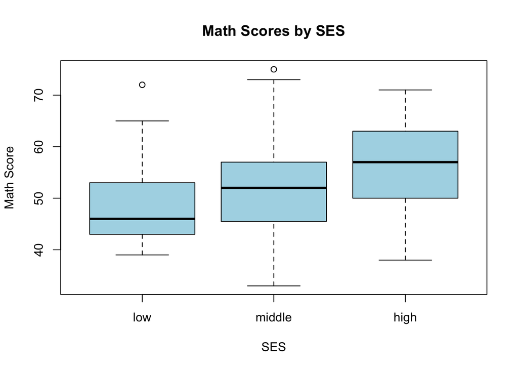

### Conditions necessary for valid ANOVA inference

#### 1. Independence

Independence means that the observations in each group are independent from the observations in every other groups. Moreover, observations within each group are independent of one another, which can be fulfilled through random sampling. So, this data seems to meet the condition of independence.

#### 2. Normality

##### (i.) Q-Q plot

To check whether this data follow a normality visually, we made a normal probability plot (which is also called a Q-Q plot). It compares the observed quantiles of the data to the expected quantiles of a normal distribution. If the data points are located close to a straight line, it means that the data follow a normality. So, based on the Q-Q plot, it seems that the data of math doesn’t follow a normality.

**Figure 2. The Q-Q Plot for the math scores**

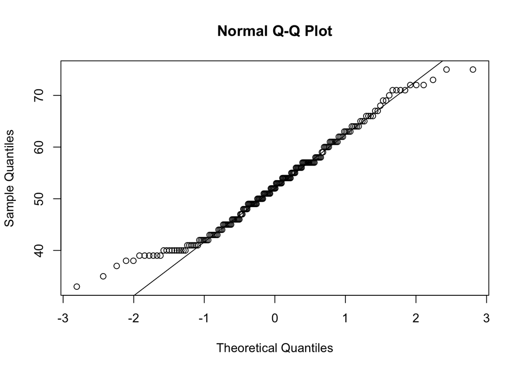

#### 3. Homogeneity of variance

##### (i.) Box plot

**Figure 3. The boxplot for the math scores by SES**

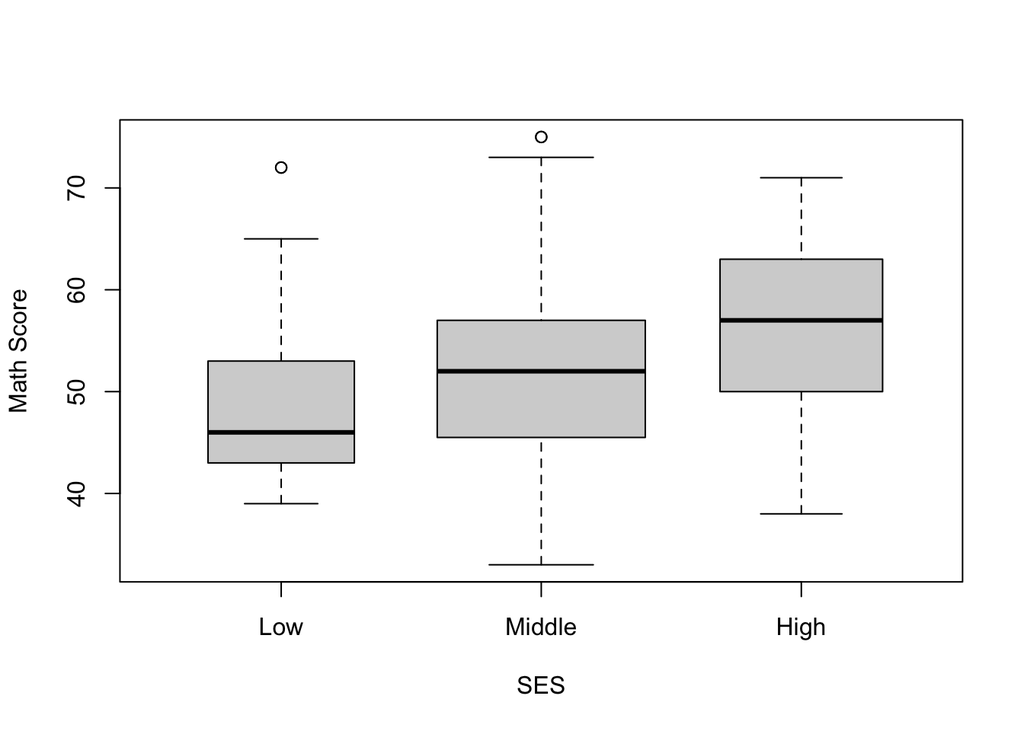

##### (ii.) Levene’s test

We used leveneTest, rather than Bartlett’s test since the data does not follow a normality. In other words, we can use Levene’s test, even in the case when the assumption of normality is not fulfilled. The null hypothesis is that the variances are equal. Therefore, we do not have sufficient evidence to reject the null hypothesis that the variance of ‘math’ are equal depending on SES ($p$ = 0.81). However, it is important to check some conditions before we use the Levene’s test, such as an independence, data, outliers, sample size, and group size.

### Bootstrapped Confidence Interval

Because our dependent variable does not meet the assumption of normality, we should not use the ANOVA calculated above as an indicator of whether there is a significant difference between conditions. Therefore, we used bootstrapping to obtain a 95% confidence interval for the difference in the maximum mean and the minimum mean for each socioeconomic group. In our sample, the difference in the maximum mean and the minimum mean of the groups was 7. Based on our results, we can say with 95% certainty the difference in the maximum mean and the minimum mean ranges from 3.68 to 10.25, which shows there are there are likely differences in math scores among the three SES conditions.

### Conclusion

Our team compared the math test performance of a random sample of high school seniors from three different socioeconomic status categories (low, middle, and high). The mean math test score for the low SES group was 49.17, for the middle SES group was 52.21, and the high SES group was 56.17. In our sample, the difference in the maximum mean and the minimum mean math scores of the groups was 7 points. An omnibus ANOVA revealed a significant difference between SES group on math scores, but upon inspection of the distribution of math scores, we found it did not meet the normality of the distribution criterion for valid inference using ANOVA. For this reason, we used bootstrapping to calculate a 95% confidence interval for the difference in the maximum mean and the minimum mean for each socioeconomic group and found that we can be 955 confident that in the greater population, the difference in the maximum mean and the minimum mean ranges from 3.68 to 10.25. From this, we can say there is very likely a difference in math test scores across socioeconomic groups.